```python
%%html
<style>
@import url('https://fonts.googleapis.com/css?family=Roboto&effect=3d|brick-sign|');
span {font-family:Roboto; color:black; text-shadow:4px 4px 4px #aaa;}
h1,h2 {font-family:Roboto; color:slategray; text-shadow:4px 4px 4px #aaa;}
div.output_subarea, div.output_area pre{font-family:Roboto; font_size:120%; color:darkblue;}
</style>
```

# Ссылки / Links

[Математический анализ. Первый семестр.](http://lectoriy.mipt.ru/course/Maths-Basic_Analysis/lectures)

[Непрерывность](https://ru.coursera.org/lecture/matematika-dlya-vseh/opriedielieniie-priediela-1-xzyQ8)

[Функция. Предел функции в точке и бесконечности. Теоремы о пределах](https://www.youtube.com/watch?v=wH2kbfndYjM)

[Бесконечно малые и бесконечно большие функции и их свойства](https://www.youtube.com/watch?v=1vigfVdPlOE)

[Непрерывность функции. Основные элементарные функции. Замечательные пределы.](https://www.youtube.com/watch?v=0J4Wm_4YKdw&t=57s)

[Примеры решения задач](http://ru.solverbook.com/primery-reshenij/)

[Пределы с корнями: примеры решений](https://xn--24-6kcaa2awqnc8dd.xn--p1ai/predely-s-kornyami.html)

[Limits and continuity](https://www.khanacademy.org/math/ap-calculus-ab/ab-limits-new)

# Задачи / Problems

[Сборник задач по математике для втузов. В 4-х частях. Под ред. Ефимова А.В., Поспелова А.С. (Часть 2)](https://drive.google.com/file/d/1qUN5t1IQdWvlRf0gdVYZ87MznWUaHq2x/view)

```python
import math, sympy, numpy
from sympy import *
sympy.init_printing(use_unicode=True)
import pylab as plt
%matplotlib inline
```

#### # 5.262

$\large{\displaystyle{\lim_{x \to 1} \frac{1} {x} = 1}}$

$ f(x) = 1/x \implies D(f) = (-\infty,0) \cup (0, +\infty)$

$ \forall \varepsilon > 0 \ \exists \delta(\varepsilon) > 0: 0 < | x - x_0 | < \delta(\varepsilon) \implies | f(x) - a | < \varepsilon, \ \forall x $

$ 0 < | x - 1 | < \delta(\varepsilon) \implies | \frac{1}{x} - 1 | < \varepsilon, \ \forall x $

```python
-0.1/(1 + 0.1), -0.1/(1-0.1), -0.1/(1 + 0.1) > -0.1/(1-0.1)
```

```
(-0.09090909090909091, -0.11111111111111112, True)
```

```python
e = [0.1, 0.01, 0.001]
for el in e:
    print ('ε =', el, '; δ(ε) =', round(el/(1-el),6))
```

```
ε = 0.1 ; δ(ε) = 0.111111
ε = 0.01 ; δ(ε) = 0.010101
ε = 0.001 ; δ(ε) = 0.001001
```

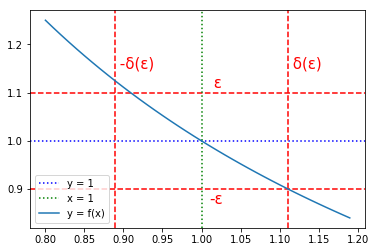

```python
def f(x): return 1/x
x = numpy.arange(0.8, 1.2,0.01)
y = [f(e) for e in x]
plt.axhline(1+0.1, c='r', ls='--'); plt.axvline(1+0.1/(1-0.1), c='r', ls='--')
plt.text(1.01,1.11,' ε', color='r',fontsize=15)
plt.text(1+0.1/(1-0.1),1.15,' δ(ε)', color='r',fontsize=15)
plt.axhline(1, ls='dotted', label='y = 1', c='b'); plt.axvline(1, ls='dotted', label='x = 1', c='g');
plt.axhline(1-0.1, c='r', ls='--'); plt.axvline(1-0.1/(1-0.1), c='r', ls='--')
plt.text(1.01,0.87,'-ε', color='r',fontsize=15)
plt.text(1-0.1/(1-0.1),1.15,' -δ(ε)', color='r',fontsize=15)
plt.plot(x,y,label='y = f(x)'); plt.legend(loc=3);
```

#### # 5.265

$\large{\displaystyle{\lim_{x \to 1-0} f(x) = - \infty}}$

$ \forall E > 0 \ \exists \delta > 0 \ | \ \forall x : - \delta < x - 1 < 0 \implies f(x) < - E $

#### # 5.267

$\large{\displaystyle{\lim_{x \to +\infty} f(x) = + \infty}}$

$ \forall E > 0 \ \exists \Delta > 0 \ | \ \forall x : x > \Delta \implies f(x) > E $

#### # 5.269

$\large{\displaystyle{\lim_{x \to \infty} f(x) = 2}}$

$ \forall \varepsilon > 0 \ \exists \Delta > 0 \ | \ \forall x : |x| > \Delta \implies \mid f(x) - 2 \mid < \varepsilon $

#### # 5.271

$\large{\displaystyle{\lim_{x \to -\infty} f(x) = \infty}}$

$ \forall E > 0 \ \exists \Delta > 0 \ | \ \forall x : - \Delta < x < 0 \implies \mid f(x)\mid > E $

#### # 5.272

$\large{\displaystyle{\lim_{x \to 0} \frac{x^2 - 2} {3x^2 - 5x + 1} }} = \frac {0^2 - 2}{3 * 0^2 - 5 * 0 + 1} = -2$

```python
from sympy.abc import x
sympy.limit((x ** 2 - 2) / (3 * x ** 2 - 5 * x + 1), x, 0)
```

$$-2$$

```python
def f(x): return (x ** 2 - 2) / (3 * x ** 2 - 5 * x + 1)
f(0)
```

$$-2.0$$

#### # 5.280

$\large{\displaystyle{\lim_{x \to \frac{1}{2}} \frac{8 * x^3 - 1} {6 * x^2 - 5 * x + 1}}}$

```python
x = symbols('x')
sympy.limit((8 * x ** 3 - 1)/(6 * x ** 2 - 5 * x + 1), x, 0.5 )
```

$$6.0$$

### $\frac{(2 * x - 1) * ( 4 * x^2 + 2 * x + 1)} {(2 * x - 1) * ( 3 * x - 1)} = \frac{( 4 * x^2 + 2 * x + 1)} {( 3 * x - 1)}$

```python
def f(x): return (4 * x ** 2 + 2 * x + 1) / (3 * x - 1)
f(1/2)
```

$$6.0$$

#### # 5.282

$\large{\displaystyle{\lim_{x \to \infty} (\frac{x^3 } {2 x^2 - 1} - \frac{x^2 } {2 x + 1})}}$

### $\frac{x^3 ( 2x + 1) - x^2 (2 x^2 - 1)} {(2 x^2 - 1) ( 2x + 1)} = \frac{x^3 + x^2} {4 x^3 + 2 x^2 - 2x - 1}$

$\large{\displaystyle{\lim_{x \to \infty} \frac{x^3 + x^2} {4 x^3 + 2 x^2 - 2x - 1} = \frac{1}{4}}}$

```python
x = symbols('x')
sympy.limit((x ** 3 / (2 * x ** 2 - 1) - x ** 2 / (2 * x + 1)), x, oo )
```

$$\frac{1}{4}$$

#### # 5.285

$\large{\displaystyle{\lim_{x \to 1} \bigg(\frac{x + 2 } {x^2 - 5x + 4} + \frac{x - 4} {3(x^2 - 3x + 2)}\bigg)}}$

### $\frac{x + 2 } {x^2 - 5x + 4} + \frac{x - 4} {3(x^2 - 3x + 2)} = \frac{x + 2 } {(x - 1)(x - 4)} + \frac{x - 4} {3(x - 1)(x - 2)} = $

### $ = \frac{3(x + 2)(x - 2) + (x - 4)^2} {3(x - 1)(x - 2)(x - 4)} = \frac{3x^2 - 12 + x^2 - 8x + 16} {3(x - 1)(x - 2)(x - 4)} = $

### $ = \frac{4x^2 - 8x + 4} {3(x - 1)(x - 2)(x - 4)} = \frac{4(x^2 - 2x + 1)} {3(x - 1)(x - 2)(x - 4)} = $

### $ = \frac{4(x - 1)^2} {3(x - 1)(x - 2)(x - 4)} = \frac{4(x - 1)} {3(x - 2)(x - 4)} $

$\large{\displaystyle{\lim_{x \to 1} \frac{4(x - 1)} {3(x - 2)(x - 4)} = \frac{4(1 - 1)} {3(1 - 2)(1 - 4)} = 0}}$

```python
x = symbols('x')
sympy.limit(((x + 2) / (x ** 2 - 5 * x + 4) + (x - 4) / (3 * (x ** 2 - 3 * x + 2))), x, 1 )
```

$$0$$

#### # 5.291

$\large{\displaystyle{\lim_{h \to 0} \frac{\sqrt{x + h} - \sqrt{x}}{h} }, x > 0}$

### $\frac{\sqrt{x + h} - \sqrt{x}}{h} = \frac{(\sqrt{x + h} - \sqrt{x}) * (\sqrt{x + h} + \sqrt{x})}{h * (\sqrt{x + h} + \sqrt{x})} = \frac{x + h - x}{h * (\sqrt{x + h} + \sqrt{x})} = \frac{h }{h * (\sqrt{x + h} + \sqrt{x})} = \frac{1}{\sqrt{x + h} + \sqrt{x}}$

$\large{\displaystyle{\lim_{h \to 0} \frac{1}{\sqrt{x + h} + \sqrt{x}}} = \frac{1}{2 \sqrt{x}} , x > 0}$

```python
h = symbols('h')
sympy.limit(((x + h) ** 0.5 - x ** 0.5) / h, h, 0)
```

$$\frac{0.5}{x^{0.5}}$$

#### # 5.297

$\large{\displaystyle{\lim_{x \to 0} \frac{\sqrt{x^2 + 4} - 2}{\sqrt{x^2 + 9} - 3} }}$

### $\frac{\sqrt{x^2 + 4} - 2}{\sqrt{x^2 + 9} - 3} = \frac{(\sqrt{x^2 + 4} - 2) (\sqrt{x^2 + 9} + 3)}{(\sqrt{x^2 + 9} - 3) (\sqrt{x^2 + 9} + 3)} = \frac{(\sqrt{x^2 + 4} - 2) (\sqrt{x^2 + 9} + 3)}{x^2 } = $

### $= \frac{(\sqrt{x^2 + 4} - 2) (\sqrt{x^2 + 9} + 3) (\sqrt{x^2 + 4} + 2) }{x^2 (\sqrt{x^2 + 4} + 2)} = \frac{x^2 (\sqrt{x^2 + 9} + 3)}{x^2 (\sqrt{x^2 + 4} + 2)} = \frac{ \sqrt{x^2 + 9} + 3}{\sqrt{x^2 + 4} + 2}$

$\large{\displaystyle{\lim_{x \to 0} \frac{\sqrt{x^2 + 9} + 3}{\sqrt{x^2 + 4} + 2} }} = \frac{3 + 3} {2 + 2} = 1.5$

```python
x = symbols('x')
sympy.limit(((x ** 2 + 4) ** 0.5 - 2) / ((x ** 2 + 9) ** 0.5 - 3), x, 0)
```

$$1.5$$

#### # 5.299

$\large{\displaystyle{\lim_{x \to +\infty} (\sqrt{x - a} - \sqrt{x})}}$

### $\sqrt{x - a} - \sqrt{x} = \frac{(\sqrt{x - a} - \sqrt{x})(\sqrt{x - a} + \sqrt{x})}{\sqrt{x - a} + \sqrt{x}} = \frac{ - a}{\sqrt{x - a} + \sqrt{x}}$

$\large{\displaystyle{\lim_{x \to +\infty} \frac{ - a}{\sqrt{x - a} + \sqrt{x}}}} = \frac{-a} {+\infty} = 0$

```python
x,a = symbols('x a')
sympy.limit(- a / ((x ** 2 - a) ** 0.5 + x ** 0.5 ), x, +oo)
```

$$0$$

#### # 5.301

$\large{\displaystyle{\lim_{x \to \infty} (\sqrt{4x^2 - 7x + 4} - 2x)}}$

### $ \sqrt{4x^2 - 7x + 4} - 2x = \frac{(\sqrt{4x^2 - 7x + 4} - 2x)(\sqrt{4x^2 - 7x + 4} + 2x)}{\sqrt{4x^2 - 7x + 4} + 2x} = $

### $ = \frac{4x^2 - 7x + 4 - 4x^2}{\sqrt{4x^2 - 7x + 4} + 2x} = \frac{- 7x + 4}{2x(\sqrt{1 - 7/4x + 1/x^2} + 1)} = $

### $ = \frac{- 7}{2(\sqrt{1 - 7/4x + 1/x^2} + 1)} + \frac{2}{x(\sqrt{1 - 7/4x + 1/x^2} + 1)}$

$\large{\displaystyle{\lim_{x \to \infty} \bigg(\frac{- 7}{2(\sqrt{1 - 7/4x + 1/x^2} + 1)} + \frac{2}{x(\sqrt{1 - 7/4x + 1/x^2} + 1)}\bigg)}} = \frac{-7}{2 * (1 + 1)} + 0 = -1.75$

```python
x = symbols('x')
sympy.limit(((4 * x ** 2 - 7 * x + 4) ** 0.5 - 2 * x) , x, oo)
```

$$-1.75$$

#### # 5.302

$\large{\displaystyle{\lim_{x \to \infty} x ^ {\frac{3}{2}} (\sqrt{x^3 + 2} - \sqrt{x^3 - 2})}}$

### $x ^ {\frac{3}{2}} (\sqrt{x^3 + 2} - \sqrt{x^3 - 2}) = x ^ {\frac{3}{2}} \frac{(\sqrt{x^3 + 2} - \sqrt{x^3 - 2})(\sqrt{x^3 + 2} + \sqrt{x^3 - 2})}{\sqrt{x^3 + 2} + \sqrt{x^3 - 2}} = $

### $ = \frac{4x ^ {\frac{3}{2}} }{\sqrt{x^3 + 2} + \sqrt{x^3 - 2}} = \frac{4x ^ {\frac{3}{2}} }{x ^ {\frac{3}{2}}(\sqrt{1 + 2/x^3} + \sqrt{1 - 2/x^3})} = \frac{4 }{\sqrt{1 + 2/x^3} + \sqrt{1 - 2/x^3}}$

$\large{\displaystyle{\lim_{x \to \infty} \frac{4 }{\sqrt{1 + 2/x^3} + \sqrt{1 - 2/x^3}}}} = \frac{4}{\sqrt{1 + 0} + \sqrt{1-0}} = \frac{4}{2} = 2$

```python
x = symbols('x')
sympy.limit(x ** 1.5 * ((x ** 3 + 2) ** 0.5 - (x ** 3 - 2) ** 0.5) , x, oo)
```

$$2.0$$